# Introduction to Python

Python is a high-level, interpreted programming language known for its simplicity and readability. It is widely used in various domains, including web development, data analysis, text analysis, artificial intelligence, scientific computing, and more. Python's versatility and extensive library ecosystem make it a popular choice for both beginners and experienced developers.

## Example: Hello World in Python

```
print("Hello, World!")
```

## Applications of Python

| **Category** | **Libraries/Tools** | **Example Use Case** |
| --- | --- | --- |
| Web Development | Django, Flask | Build a blog, dashboard, or interactive visualization |
| Data Science | pandas, NumPy, Matplotlib | Analyze, clean, and visualize quanitative or qualitative data |
| Automation | os, shutil, sched | Rename a batch of files |
| Text Analyis | spaCy, NLTK | Sentiment analysis on reviews |
| Mapping | GeoPandas, Folium, geopy | Plot locations on an interactive map |
| Data Management | pandas, `csv`, `xlm`, `json` | Clean and standardize metadata for a digital collection |
| Webscraping | BeautifulSoup, Scrapy | Collect daily weather data |
| Machine Learning | scikit-learn, TensorFlow | Classify emails as spam |
| Data Processing/Cleaning | pandas, regex, `csv` | Clean historical census data for analysis |
| Education | Jupyter | Provide introductory material in an easy format |

## Libraries

Libraries are collections of code, that you can essentially "check-out" to use. Once you import the library, you call different modules or functions within that library to perform specific tasks.

[figure not shown]

```python
## Here we're going to import a couple of libraries that we will use in our codes.
## Notice that we are using the "as" keyword to give aliases to the libraries - this is a common practice to make the code cleaner and easier to read.
import pandas as pd
import numpy as np
import matplotlib.pyplot as plt
```

## Data Types

Data types are the kinds of values you can use in Python. Every value in Python has a type and unlike other many other languages you do not have to explicitly set these types. However because of that you have to be diligent to keep track of the types as you go.

Each type will have it's own set of functions and expressions that can performed.

### Basic Data Types

| Type | Example | Description |
| --- | --- | --- |
| `int` | 42, -2, 3244235 | Whole numbers (positive or negative) |
| `float` | 3.193727, 0.55, -2423.34243 | Decimal numbers |
| `str` | "hello", "hello, world", "h" | Text (string of characters) |
| `bool` | True, False | Boolean values (logic, conditionals) |

```python
## Now let's go through some examples of these data types

## number of pages
300
311 + 403 + 267 + 149
num_pages = 311 + 403 + 267 + 149
print(num_pages)
```

```
1130
```

```python
avg_pages = num_pages / 4
print(avg_pages)
```

```
282.5
```

We can also do other types of mathematics:

| Operation | Symbol | Example | Output |
| --- | --- | --- | --- |
| Addition | `+` | `1 + 1` | `2` |
| Subtraction | `-` | `2 - 1` | `1` |
| Multiplication | `*` | `2 * 2` | `4` |
| Division | `/` | `3 / 1` | `3` |
| Division (floor) | `//` | `10 // 3` | `3` |
| Remainder | `%` | `10 % 3` | `1` |
| Exponent | `**` | `3 ** 2` | `9` |

**Try it Yourself**: Let's combine what we know about variable names, expressions, and int/floats to create a more complex string of commands to figure out the cost of book. Let's say you're buying a book from a independent bookstore and there's both a sales tax of 5% and a shipping fee of 12%. Let's first figure out the sales tax and then the shipping fee if the item is $27 before calculating the total cost.

```python
item_cost = 27
sales_tax = 0.05 * 27
shipping_fee = 0.12 * 27
total_cost = item_cost + sales_tax + shipping_fee
print(total_cost, sales_tax, shipping_fee)
```

```
31.59 1.35 3.2399999999999998
```

```python
## We can also convert numbers to strings
num_pages_str = str(num_pages)
print(num_pages_str, type(num_pages_str))
print(num_pages, type(num_pages))
```

```
1130 <class 'str'>
1130 <class 'int'>
```

```python
## Now let's look more at strings
book_title = "The Hitchhiker's Guide to the Galaxy"
print(book_title)
```

```
The Hitchhiker's Guide to the Galaxy
```

```python
## we can do a couple different things with strings, like finding their length
title_length = len(book_title)

## or we can add strings together
author_name = "Douglas Adams"
full_title = book_title + " by " + author_name
print(full_title)

## we can also strip characters from strings, select specific words or characters, and convert them to uppercase or lowercase
stripped_title = book_title.strip("Galaxy")
print(stripped_title)

last_word = book_title.split()[-1]
print(last_word)

uppercase_title = book_title.upper()
print(uppercase_title)

lowercase_title = book_title.lower()
print(lowercase_title)
```

```
The Hitchhiker's Guide to the Galaxy by Douglas Adams
The Hitchhiker's Guide to the
Galaxy
THE HITCHHIKER'S GUIDE TO THE GALAXY
the hitchhiker's guide to the galaxy
```

### Collection Data Types

| Type | Example | Description |
| --- | --- | --- |
| `list` | `[1, 2, 3]` or `[99, 'hello', False]` | Ordered, changeable sequence |
| `dict` | `{"key":"value"}` or `{"Ada":['Librarian', 42, "Carpenter"]}` | Key-value pairs |
| `tuple` | `(1, 2, 3, 3)` | Ordered, unchangeable sequence |
| `set` | `set(1, 2, 3)` | Unordered collection of unique values |

```python
## Now let's look at lists, which are a way to store multiple items in a single variable
book_titles = ["The Hitchhiker's Guide to the Galaxy",
               "1984",
               "To Kill a Mockingbird",
               "Pride and Prejudice"]
print(book_titles)
print(type(book_titles))
```

[output not shown]

```python
## we can select specific items from a list using their index (Python always starts counting at 0)
first_book = book_titles[0]
print(first_book)

## an easy way to get the last item is to use a negative index
last_book = book_titles[-1]
print(last_book)

## we can also add items to a list using append()
book_titles.append("Brave New World")
print(book_titles)

## or we can remove items using remove()
book_titles.remove("To Kill a Mockingbird")
print(book_titles)

## we can also sort lists
book_titles.sort()
print(book_titles)
```

```python
## now let's look at dictionaries, which are a way to store key-value pairs

book_info = {
    "title": "The Hitchhiker's Guide to the Galaxy",
    "author": "Douglas Adams",
    "pages": 216,
    "published_year": 1979
}
print(book_info)
print(type(book_info))
```

[output not shown]

```python
## we can access specific values in a dictionary using their keys
title = book_info["title"]
print(title)

## we can also add new key-value pairs to a dictionary
book_info["genre"] = "Science Fiction"
print(book_info)

## or we can remove key-value pairs using the del keyword
del book_info["published_year"]
print(book_info)
```

```python
## we can have dictionaries within dictionaries, which is useful for more complex data structures
book_collection = {
    24234: {
        "title": "The Hitchhiker's Guide to the Galaxy",
        "author": "Douglas Adams",
        "pages": 216
    },
    24235: {
        "title": "1984",
        "author": "George Orwell",
        "pages": 368
    }
}
print(book_collection)
```

[output not shown]

```python
## we can access specific books in the collection using their keys
book_id = 24235
book_details = book_collection[book_id]
print(book_details)

## we can also access specific values within the nested dictionary
book_title = book_collection[book_id]["title"]
print(book_title)
```

## Loops and Conditionals

### Conditionals or Comparisons

Sometimes we want to be able to compare different variables or expressions. This could be to find matching amounts/text or perhaps you want to identify when a specifc number rises above a certain threshold. We can do this through using comparison statements.

Reminder: Booleans - represent either True or False often in logic or conditional statements

```python
## let's look at some examples of using conditional statements

book1_pages = 216
book2_pages = 328

book1_pages > book2_pages
```

```
False
```

### Methods of comparison

| Comparison | Operator |
| --- | --- |
| Less than | `<` |
| Greater than | `>` |
| Less than or equal to | `<=` |
| Greater than or equal to | `>=` |
| Equal | `==` |
| Not equal | `!=` |

```python
## We can combine if statements with conditional operators to help move through the code
if book1_pages > book2_pages:
    print("Book 1 has more pages than Book 2.")
elif book1_pages < book2_pages:
    print("Book 2 has more pages than Book 1.")
else:
    print("Both books have the same number of pages.")
```

[output not shown]

```python
## we can also combine multiple conditions together using keywords like 'and', 'or', and 'not'
if book1_pages > 200 and book2_pages > 300:
    print("Both books have a significant number of pages.")
else:
    print("At least one book does not have a significant number of pages.")
```

### Loops (Automation)

Sometimes we will want to repeat the exact same task again and again. In python, loops allow us to create this type of automations to repeat tasks efficiently. The most common types of loops are using *for* and *while*. A for loop is often used to iterate over a sequence such as a list executing the same code for each element in the list. A while loop continues to run as long as a specified condition remains true.

```python
## The final piece is to look at loops which allows us to iterate over our collection data types

## Let's start with a simple for loop to iterate over a list of book titles
for title in book_titles:
    print(title)
```

[output not shown]

```python
## we can also use the range function to iterate over a list by the index values
for i in range(len(book_titles)):
    print(f"Book {i + 1}: {book_titles[i]}")
```

```python
## now let's combine loops and conditional statements
for book_id, details in book_collection.items():
    if details["pages"] > 300:
        print(f"Book ID {book_id} has more than 300 pages: {details['title']}")
```

## Tables

When working with data in Python, we often organize it in a table with rows and columns. The most powerful tool for working with tables is a library called `pandas` which makes it easy to load data from csv and Excel files, view and explore datasets, filter and clean data, calculate statistics, and prepare data for visualization.

Tables are stored in an object called a DataFrame.

```python
## We're going to start by using Pandas to read in a CSV file that contains metadata about novels
df = pd.read_csv('top-500-novels-metadata_2025-01-11.csv')  ## https://www.responsible-datasets-in-context.com/posts/top-500-novels/top-500-novels.html?tab=data-essay#whats-in-the-data
df
```

|  | top_500_rank | title | author | pub_year | orig_lang | genre | author_birth | author_death | author_gender | author_primary_lang | ... | gr_num_ratings | gr_num_reviews | gr_avg_rating_rank | gr_num_ratings_rank | oclc_owi | author_viaf | gr_url | wiki_url | pg_eng_url | pg_orig_url |
| --- | --- | --- | --- | --- | --- | --- | --- | --- | --- | --- | --- | --- | --- | --- | --- | --- | --- | --- | --- | --- | --- |
| 0 | 1 | Don Quixote | Miguel de Cervantes | 1605 | Spanish | action | 1547 | 1616 | male | spa | ... | 269,435 | 12,053 | 318 | 211 | 1.810748e+09 | 17220427.0 | https://www.goodreads.com/book/show/3836.Don_Q... | https://en.wikipedia.org/wiki/Don_Quixote | https://www.gutenberg.org/cache/epub/996/pg996... | https://www.gutenberg.org/cache/epub/2000/pg20... |
| 1 | 2 | Alice's Adventures in Wonderland | Lewis Carroll | 1865 | English | fantasy | 1832 | 1898 | male | eng | ... | 561,016 | 15,380 | 172 | 133 | 1.156132e+10 | 66462036.0 | https://www.goodreads.com/book/show/24213.Alic... | https://en.wikipedia.org/wiki/Alice%27s_Advent... | https://www.gutenberg.org/cache/epub/11/pg11.txt | NaN |
| 2 | 3 | The Adventures of Huckleberry Finn | Mark Twain | 1884 | English | action | 1835 | 1910 | male | eng | ... | 1,262,480 | 19,440 | 373 | 68 | 3.373178e+09 | 50566653.0 | https://www.goodreads.com/book/show/2956.The_A... | https://en.wikipedia.org/wiki/Adventures_of_Hu... | https://www.gutenberg.org/cache/epub/76/pg76.txt | NaN |
| 3 | 4 | The Adventures of Tom Sawyer | Mark Twain | 1876 | English | action | 1835 | 1910 | male | eng | ... | 931,898 | 13,603 | 301 | 88 | 3.373178e+09 | 50566653.0 | https://www.goodreads.com/book/show/24583.The_... | https://en.wikipedia.org/wiki/The_Adventures_o... | https://www.gutenberg.org/cache/epub/74/pg74.txt | NaN |
| 4 | 5 | Treasure Island | Robert Louis Stevenson | 1883 | English | action | 1850 | 1894 | male | eng | ... | 486,155 | 16,307 | 368 | 145 | 3.434000e+03 | 95207986.0 | https://www.goodreads.com/book/show/295.Treasu... | https://en.wikipedia.org/wiki/Treasure_Island | https://www.gutenberg.org/cache/epub/120/pg120... | NaN |
| ... | ... | ... | ... | ... | ... | ... | ... | ... | ... | ... | ... | ... | ... | ... | ... | ... | ... | ... | ... | ... | ... |
| 495 | 496 | Stranger in a Strange Land | Robert A. Heinlein | 1961 | English | scifi | 1907 | 1988 | male | eng | ... | 311,859 | 9,961 | 310 | 190 | 7.894120e+05 | 12309757.0 | NaN | https://en.wikipedia.org/wiki/Stranger_in_a_St... | NA_not-pub-domain | NaN |
| 496 | 497 | Vision in White | Nora Roberts | 2009 | English | romance | 1965 | ALIVE | female | eng | ... | 138,445 | 4,652 | 128 | 277 | 1.559638e+08 | 66448023.0 | NaN | https://en.wikipedia.org/wiki/Vision_in_White | NA_not-pub-domain | NaN |
| 497 | 498 | The Whipping Boy | Sid Fleischman | 1986 | English | action | 1920 | 2010 | male | eng | ... | 27,444 | 1,623 | 476 | 445 | 4.415520e+08 | 66438084.0 | NaN | https://en.wikipedia.org/wiki/The_Whipping_Boy | NA_not-pub-domain | NaN |
| 498 | 499 | Room | Emma Donoghue | 2010 | English | na | 1969 | ALIVE | female | eng | ... | 801,989 | 50,594 | 171 | 101 | 4.859780e+08 | 39539889.0 | NaN | https://en.wikipedia.org/wiki/Room_(novel) | NA_not-pub-domain | NaN |
| 499 | 500 | Deception Point | Dan Brown | 2001 | English | political | 1964 | ALIVE | male | eng | ... | 658,866 | 10,464 | 420 | 122 | 6.102510e+05 | 102403515.0 | NaN | https://en.wikipedia.org/wiki/Deception_Point | NA_not-pub-domain | NaN |

500 rows × 29 columns

```python
## You can double click on the table output above to hide or collapse it.
## Notice how the table hides the middle rows and columns to make it easier to read?
## Let's change that so we can see all the columns in the DataFrame.
with pd.option_context('display.max_columns', None):
    display(df)
```

|  | top_500_rank | title | author | pub_year | orig_lang | genre | author_birth | author_death | author_gender | author_primary_lang | author_nationality | author_field_of_activity | author_occupation | oclc_holdings | oclc_eholdings | oclc_total_editions | oclc_holdings_rank | oclc_editions_rank | gr_avg_rating | gr_num_ratings | gr_num_reviews | gr_avg_rating_rank | gr_num_ratings_rank | oclc_owi | author_viaf | gr_url | wiki_url | pg_eng_url | pg_orig_url |
| --- | --- | --- | --- | --- | --- | --- | --- | --- | --- | --- | --- | --- | --- | --- | --- | --- | --- | --- | --- | --- | --- | --- | --- | --- | --- | --- | --- | --- | --- |
| 0 | 1 | Don Quixote | Miguel de Cervantes | 1605 | Spanish | action | 1547 | 1616 | male | spa | ES | NaN | soldiers,poets spanish,novelists spanish,drama... | 30840.0 | 4992.0 | 9017.0 | 9.0 | 1.0 | 3.90 | 269,435 | 12,053 | 318 | 211 | 1.810748e+09 | 17220427.0 | https://www.goodreads.com/book/show/3836.Don_Q... | https://en.wikipedia.org/wiki/Don_Quixote | https://www.gutenberg.org/cache/epub/996/pg996... | https://www.gutenberg.org/cache/epub/2000/pg20... |
| 1 | 2 | Alice's Adventures in Wonderland | Lewis Carroll | 1865 | English | fantasy | 1832 | 1898 | male | eng | GB | writing,teaching,photography,mathematics | authors,teachers,photographers,mathematicians | 24125.0 | 6698.0 | 2694.0 | 18.0 | 33.0 | 4.06 | 561,016 | 15,380 | 172 | 133 | 1.156132e+10 | 66462036.0 | https://www.goodreads.com/book/show/24213.Alic... | https://en.wikipedia.org/wiki/Alice%27s_Advent... | https://www.gutenberg.org/cache/epub/11/pg11.txt | NaN |
| 2 | 3 | The Adventures of Huckleberry Finn | Mark Twain | 1884 | English | action | 1835 | 1910 | male | eng | US | wit and humor,literature,humor | lecturers,humorists,authors | 32602.0 | 11783.0 | 4119.0 | 6.0 | 6.0 | 3.83 | 1,262,480 | 19,440 | 373 | 68 | 3.373178e+09 | 50566653.0 | https://www.goodreads.com/book/show/2956.The_A... | https://en.wikipedia.org/wiki/Adventures_of_Hu... | https://www.gutenberg.org/cache/epub/76/pg76.txt | NaN |
| 3 | 4 | The Adventures of Tom Sawyer | Mark Twain | 1876 | English | action | 1835 | 1910 | male | eng | US | wit and humor,literature,humor | lecturers,humorists,authors | 32602.0 | 11783.0 | 4119.0 | 7.0 | 7.0 | 3.92 | 931,898 | 13,603 | 301 | 88 | 3.373178e+09 | 50566653.0 | https://www.goodreads.com/book/show/24583.The_... | https://en.wikipedia.org/wiki/The_Adventures_o... | https://www.gutenberg.org/cache/epub/74/pg74.txt | NaN |
| 4 | 5 | Treasure Island | Robert Louis Stevenson | 1883 | English | action | 1850 | 1894 | male | eng | GB | NaN | travel writers,poets,novelists | 37702.0 | 14286.0 | 5555.0 | 1.0 | 2.0 | 3.84 | 486,155 | 16,307 | 368 | 145 | 3.434000e+03 | 95207986.0 | https://www.goodreads.com/book/show/295.Treasu... | https://en.wikipedia.org/wiki/Treasure_Island | https://www.gutenberg.org/cache/epub/120/pg120... | NaN |
| ... | ... | ... | ... | ... | ... | ... | ... | ... | ... | ... | ... | ... | ... | ... | ... | ... | ... | ... | ... | ... | ... | ... | ... | ... | ... | ... | ... | ... | ... |
| 495 | 496 | Stranger in a Strange Land | Robert A. Heinlein | 1961 | English | scifi | 1907 | 1988 | male | eng | US | science fiction | authors american | 6352.0 | 268.0 | 273.0 | 421.0 | 350.0 | 3.92 | 311,859 | 9,961 | 310 | 190 | 7.894120e+05 | 12309757.0 | NaN | https://en.wikipedia.org/wiki/Stranger_in_a_St... | NA_not-pub-domain | NaN |
| 496 | 497 | Vision in White | Nora Roberts | 2009 | English | romance | 1965 | ALIVE | female | eng | US | novels,fiction | novelists | 4499.0 | 458.0 | 111.0 | 487.0 | 474.0 | 4.12 | 138,445 | 4,652 | 128 | 277 | 1.559638e+08 | 66448023.0 | NaN | https://en.wikipedia.org/wiki/Vision_in_White | NA_not-pub-domain | NaN |
| 497 | 498 | The Whipping Boy | Sid Fleischman | 1986 | English | action | 1920 | 2010 | male | eng | US | NaN | NaN | 6113.0 | 184.0 | 106.0 | 447.0 | 476.0 | 3.59 | 27,444 | 1,623 | 476 | 445 | 4.415520e+08 | 66438084.0 | NaN | https://en.wikipedia.org/wiki/The_Whipping_Boy | NA_not-pub-domain | NaN |
| 498 | 499 | Room | Emma Donoghue | 2010 | English | na | 1969 | ALIVE | female | eng | IE | fiction,drama,motion picture authorship,editing | novelists,authors,screenwriters,editors,dramat... | 5963.0 | 380.0 | 215.0 | 458.0 | 389.0 | 4.07 | 801,989 | 50,594 | 171 | 101 | 4.859780e+08 | 39539889.0 | NaN | https://en.wikipedia.org/wiki/Room_(novel) | NA_not-pub-domain | NaN |
| 499 | 500 | Deception Point | Dan Brown | 2001 | English | political | 1964 | ALIVE | male | eng | US | suspense fiction,fiction | novelists american,authors american | 5382.0 | 229.0 | 240.0 | 474.0 | 373.0 | 3.76 | 658,866 | 10,464 | 420 | 122 | 6.102510e+05 | 102403515.0 | NaN | https://en.wikipedia.org/wiki/Deception_Point | NA_not-pub-domain | NaN |

500 rows × 29 columns

```python
## we can do some basic analyis on the dataset
print(df.shape)  # Get the number of rows and columns in the DataFrame
print(df.info())  # Get information about the DataFrame, including data types and non-null counts
```

```
(500, 29)
<class 'pandas.core.frame.DataFrame'>
RangeIndex: 500 entries, 0 to 499
Data columns (total 29 columns):
 #   Column                    Non-Null Count  Dtype
---  ------                    --------------  -----
 0   top_500_rank              500 non-null    int64
 1   title                     500 non-null    object
 2   author                    500 non-null    object
 3   pub_year                  500 non-null    int64
 4   orig_lang                 500 non-null    object
 5   genre                     500 non-null    object
 6   author_birth              499 non-null    object
 7   author_death              496 non-null    object
 8   author_gender             500 non-null    object
```

[output cut: 23 more lines]

```python
print(df.describe())  # Get summary statistics for numerical columns
```

```
       top_500_rank     pub_year  oclc_holdings  oclc_eholdings  \
count    500.000000   500.000000     495.000000      495.000000
mean     250.500000  1932.132000   10401.438384     2218.593939
std      144.481833    84.306546    5694.509003     3084.595715
min        1.000000  1021.000000     996.000000       25.000000
25%      125.750000  1900.000000    6800.000000      352.000000
50%      250.500000  1948.000000    8318.000000      558.000000
75%      375.250000  1989.000000   12184.000000     3223.000000
max      500.000000  2015.000000   37702.000000    15545.000000

       oclc_total_editions  oclc_holdings_rank  oclc_editions_rank  \
count           495.000000          495.000000          495.000000
mean            896.642424          248.000000          248.000000
std            1019.015572          143.038456          143.038456
min              21.000000            1.000000            1.000000
25%             241.000000          124.500000          124.500000
50%             485.000000          248.000000          248.000000
75%            1207.500000          371.500000          371.500000
max            9017.000000          495.000000          495.000000

       gr_avg_rating  gr_avg_rating_rank  gr_num_ratings_rank      oclc_owi  \
count     500.000000          500.000000           500.000000  4.950000e+02
mean        3.971440          250.500000           250.500000  1.602208e+09
std         0.227688          144.481833           144.481833  2.675299e+09
min         3.290000            1.000000             1.000000  1.040000e+03
25%         3.830000          125.750000           125.750000  3.972875e+05
50%         3.980000          250.500000           250.500000  1.675603e+07
75%         4.120000          375.250000           375.250000  2.830459e+09
max         4.620000          500.000000           500.000000  1.239276e+10

        author_viaf
count  5.000000e+02
mean   4.747193e+18
std    1.021245e+20
min    6.293000e+03
25%    3.692003e+07
50%    6.897730e+07
75%    9.699450e+07
max    2.283160e+21
```

```python
df.columns
```

```
Index(['top_500_rank', 'title', 'author', 'pub_year', 'orig_lang', 'genre',
       'author_birth', 'author_death', 'author_gender', 'author_primary_lang',
       'author_nationality', 'author_field_of_activity', 'author_occupation',
       'oclc_holdings', 'oclc_eholdings', 'oclc_total_editions',
       'oclc_holdings_rank', 'oclc_editions_rank', 'gr_avg_rating',
       'gr_num_ratings', 'gr_num_reviews', 'gr_avg_rating_rank',
       'gr_num_ratings_rank', 'oclc_owi', 'author_viaf', 'gr_url', 'wiki_url',
       'pg_eng_url', 'pg_orig_url'],
      dtype='object')
```

```python
## We can select specific columns from the DataFrame by using their names
df['title']

## We can also select multiple columns by passing a list of column names
df[['title', 'author', 'pub_year']]
```

|  | title | author | pub_year |
| --- | --- | --- | --- |
| 0 | Don Quixote | Miguel de Cervantes | 1605 |
| 1 | Alice's Adventures in Wonderland | Lewis Carroll | 1865 |
| 2 | The Adventures of Huckleberry Finn | Mark Twain | 1884 |
| 3 | The Adventures of Tom Sawyer | Mark Twain | 1876 |
| 4 | Treasure Island | Robert Louis Stevenson | 1883 |
| ... | ... | ... | ... |
| 495 | Stranger in a Strange Land | Robert A. Heinlein | 1961 |
| 496 | Vision in White | Nora Roberts | 2009 |
| 497 | The Whipping Boy | Sid Fleischman | 1986 |
| 498 | Room | Emma Donoghue | 2010 |
| 499 | Deception Point | Dan Brown | 2001 |

500 rows × 3 columns

```python
## We can filter the DataFrame based on specific conditions
filtered_df = df[df['pub_year'] > 2000]  # Select rows where the year is greater than 2000
print(filtered_df)
```

```
     top_500_rank                                      title  \
87             88                          The Da Vinci Code
124           125  Harry Potter and the Order of the Phoenix
131           132                                   Twilight
145           146                            The Kite Runner
172           173                           The Hunger Games
..            ...                                        ...
492           493                                  The Shack
494           495                        The Sea of Monsters
496           497                            Vision in White
498           499                                       Room
499           500                            Deception Point

               author  pub_year orig_lang      genre author_birth  \
87          Dan Brown      2003   English    mystery         1964
```

[output cut: 77 more lines]

```python
## We can calculate statistics on specific columns
avg_holdings = df['oclc_holdings'].mean()  # Calculate the average number of OCLC holdings
print(avg_holdings)
```

```
10401.438383838384
```

**Try It Yourself**: Select a column and try to find out some basic summary statistics such as the minimum, maximum, median, mean, and mode values.

## Visualization

Now let's think about how we might continue to explore this dataset using visualizations. We're going to be using a combination of pandas' built-in plotting functions and the matplotlib library.

Matplotlib is one of the most powerful and widely used libraries for creating visualizations in Python. While other libraries such as seaborn and plotly offer stylish and interactive plots with less code, matplotlib gives you the ability to have fine-grained control over every aspect of a figure.

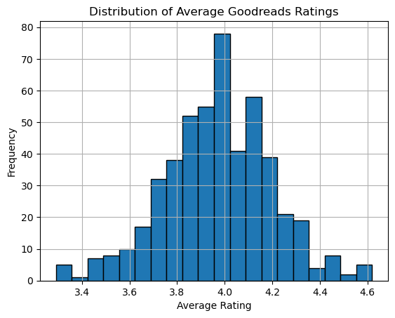

```python
## Example 1: Histograms - Used for showing the distribution of single numerical variable

df.hist('gr_avg_rating', bins=20, edgecolor='black')  ## here is where we actually create the histogram
plt.xlabel('Average Rating')  ## here we label the x-axis
plt.ylabel('Frequency')  ## here we label the y-axis
plt.title('Distribution of Average Goodreads Ratings')  ## here we give it a title
```

Now let's look at a more complicated example. We have several columns that are categorical. We might want to look at the comparison between these columns such as the example below where we examine the difference in Goodreads averages for books in the public domain versus books not in the public domain.

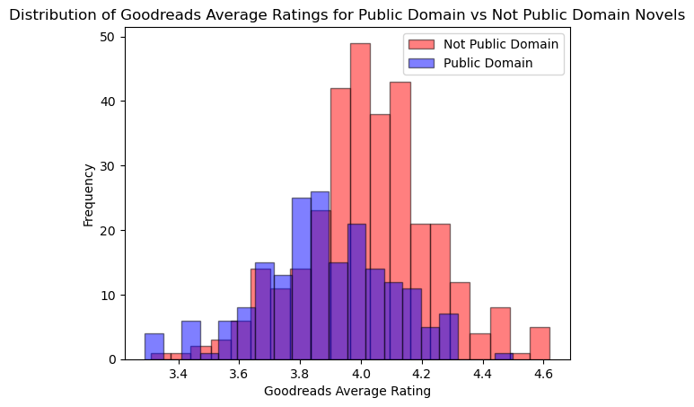

```python
notPublic = df[(df['pg_eng_url'] == 'NA_not-pub-domain') | (df['pg_eng_url'] == 'unavailable')]
Public = df[df['pg_eng_url'] != 'NA_not-pub-domain']

notPublic['PublicDomain'] = 'Not Public Domain'
Public['PublicDomain'] = 'Public Domain'
updated_table_domain = pd.concat([notPublic, Public])

plt.hist(notPublic['gr_avg_rating'], bins=20, edgecolor='black', alpha=0.5, label='Not Public Domain', color = 'red')
plt.hist(Public['gr_avg_rating'], bins=20, edgecolor='black', alpha=0.5, label='Public Domain', color = 'blue')
plt.legend()
plt.xlabel('Goodreads Average Rating')
plt.ylabel('Frequency')
plt.title('Distribution of Goodreads Average Ratings for Public Domain vs Not Public Domain Novels')
plt.show()
plt.clf()
```

[figure not shown]

```python
## we can also do this using seaborn, which is a library built on top of matplotlib that makes it easier to create complex visualizations
import seaborn as sns
sns.histplot(data=df, x='gr_avg_rating', hue = 'pg_eng_url', bins=20, kde=True, color='blue', edgecolor='black')
plt.xlabel('Average Goodreads Rating')
plt.ylabel('Frequency')
plt.title('Distribution of Average Goodreads Ratings')
plt.show()
```

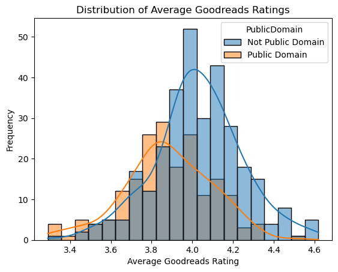

```python
sns.histplot(data=updated_table_domain, x='gr_avg_rating', hue = 'PublicDomain', bins=20, kde=True, color='blue', edgecolor='black')
plt.xlabel('Average Goodreads Rating')
plt.ylabel('Frequency')
plt.title('Distribution of Average Goodreads Ratings')
plt.show()
```

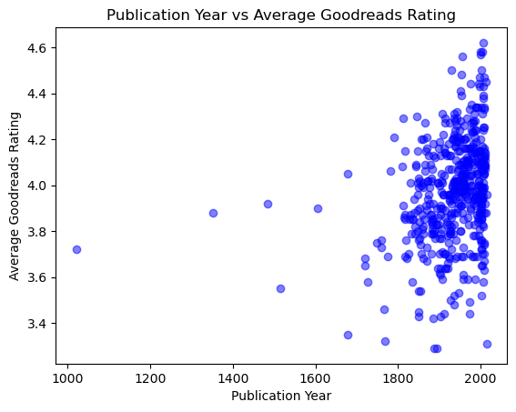

```python
## Example 2: Scatter Plots - Used for showing the relationship between two numerical variables

plt.scatter(df['pub_year'], df['gr_avg_rating'], alpha=0.5, color='blue')
plt.xlabel('Publication Year')
plt.ylabel('Average Goodreads Rating')
plt.title('Publication Year vs Average Goodreads Rating')
plt.show()
```

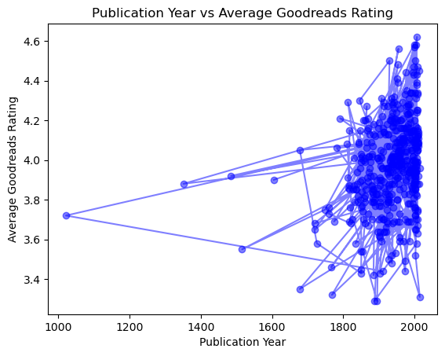

```python
## Example 3: Line Plots - Used for showing trends over time or ordered categories

plt.plot(df['pub_year'], df['gr_avg_rating'], marker='o', linestyle='-', color='blue', alpha=0.5)
plt.xlabel('Publication Year')
plt.ylabel('Average Goodreads Rating')
plt.title('Publication Year vs Average Goodreads Rating')
plt.show()
```

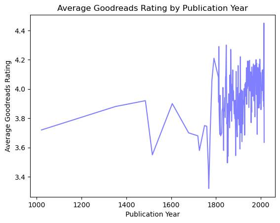

```python
## we can see that this doesn't quite work as expected because the publication years are not sorted and are not unique
## so let's try to fix that
sorted_df = df.sort_values(by='pub_year')  # Sort the DataFrame by publication year
plt.plot(sorted_df['pub_year'], sorted_df['gr_avg_rating'], marker='o', linestyle='-', color='blue', alpha=0.5)
plt.clf()

## still not quite what we want so let's group the data by publication year and get an average
grouped_df = df.groupby('pub_year')['gr_avg_rating'].mean().reset_index()  # Group by publication year and calculate the average rating
plt.plot(grouped_df['pub_year'], grouped_df['gr_avg_rating'], linestyle='-', color='blue', alpha=0.5)
plt.xlabel('Publication Year')
plt.ylabel('Average Goodreads Rating')
plt.title('Average Goodreads Rating by Publication Year')
plt.show()
```

[figure not shown]

```python
## Example 4: Bar Plots - Used for comparing categorical data
grouped_languages = df.groupby('orig_lang')['gr_avg_rating'].mean().reset_index()  # Group by original language and calculate the average rating
grouped_languages = grouped_languages.sort_values(by='gr_avg_rating', ascending=False)  # Sort by average rating

plt.figure(figsize=(12, 6))  # Set the figure size
plt.bar(grouped_languages['orig_lang'], grouped_languages['gr_avg_rating'], color='blue', alpha=0.7)
plt.xlabel('Original Language')
plt.ylabel('Average Goodreads Rating')
plt.title('Average Goodreads Rating by Original Language')
plt.xticks(rotation=45)  # Rotate x-axis labels for better readability
plt.tight_layout()  # Adjust layout to prevent overlap
```

**Try it Yourself**: Pick a column or a series of columns to explore. Try to visualize your selected data - is there any obstacles you encountered? Is the data in a form that you have to alter or manipulate or filter?

## Application: Text Analysis

Now let's put this all together.

```python
## Step 1: Pick a title to analyze.
for title in Public['title']:
    print(title)
```

```
Don Quixote
Alice's Adventures in Wonderland
The Adventures of Huckleberry Finn
The Adventures of Tom Sawyer
Treasure Island
Pride and Prejudice
Wuthering Heights
Jane Eyre
Moby Dick
The Scarlet Letter
Gulliver's Travels
The Pilgrim's Progress
A Christmas Carol
David Copperfield
A Tale of Two Cities
Little Women
Great Expectations
Frankenstein, or, the Modern Prometheus
Oliver Twist
Uncle Tom's Cabin
Crime and Punishment
Madame Bovary: Patterns of Provincial life
Dracula
The Three Musketeers
War and Peace
The Wizard of Oz
Les Misérables
The Secret Garden
The Great Gatsby
The Call of the Wild
20,000 Leagues Under the Sea
Anna Karenina
The Wind in the Willows
The Picture of Dorian Gray
The Grapes of Wrath
Sense and Sensibility
The Last of the Mohicans
Tess of the d'Urbervilles
Heidi
Ulysses
```

[output cut: 135 more lines]

```
The Rise of Silas Lapham
The Virginian: A Horseman of the Plains
King Solomon's Mines
The Princess of Cleves
The Moon and Sixpence
Looking Backward, 2000-1887
The Wings of the Dove
Dangerous Liaisons
Arrowsmith
Orlando
Flatland
Rob Roy
The Death of Ivan Ilych
Kenilworth
The Life and Opinions of Tristram Shandy
```

```python
## Step 2: Pull the data for the book you picked.

import requests ## library for making HTTP requests

url = Public[Public['title'] == "The Wizard of Oz"]['pg_eng_url'].values[0]  ## Get the URL for your chosen book
response = requests.get(url)  ## Make a GET request to the URL
if response.status_code == 200:  ## Check if the request was successful
    print("Successfully retrieved the book page.")
else:
    print(f"Failed to retrieve the book page. Status code: {response.status_code}")
```

```
Successfully retrieved the book page.
```

```python
response.text[:1000]  ## Print the first 500 characters of the response text to see the content of the page
```

```
'\ufeffThe Project Gutenberg eBook of The Wonderful Wizard of Oz\r\n    \r\nThis ebook is for the use of anyone anywhere in the United States and\r\nmost other parts of the world at no cost and with almost no restrictions\r\nwhatsoever. You may copy it, give it away or re-use it under the terms\r\no…
```

```python
## Step 3: Clean the data to remove the header and footer from the response text

## remove the header and footer from the response text
start = response.text.find("*** START OF THE PROJECT GUTENBERG EBOOK")  ## Find the start of the book text
end = response.text.find("*** END OF THE PROJECT GUTENBERG EBOOK")  ## Find the end of the book text
cleaned_text = response.text[start:end]  ## Extract the book text between the start and end markers

cleaned_text
```

```
'*** START OF THE PROJECT GUTENBERG EBOOK THE WONDERFUL WIZARD OF OZ ***\r\n\r\n[Illustration]\r\n\r\n\r\n\r\n\r\nThe Wonderful Wizard of Oz\r\n\r\nby L. Frank Baum\r\n\r\n\r\nThis book is dedicated to my good friend & comrade\r\nMy Wife\r\nL.F.B.\r\n\r\n\r\nContents\r\n\r\n Introduction\r\n Chapter…
```

```python
## Step 4: Process the cleaned text to extract words

## now let's make everything lowercase and remove any punctuation
import re ## library for regular expressions
words = re.findall(r'\b[a-z]+\b', cleaned_text.lower())

print(words[:100])  ## Print the first 100 words to see the cleaned text
print(len(words))
```

```
['start', 'of', 'the', 'project', 'gutenberg', 'ebook', 'the', 'wonderful', 'wizard', 'of', 'oz', 'illustration', 'the', 'wonderful', 'wizard', 'of', 'oz', 'by', 'l', 'frank', 'baum', 'this', 'book', 'is', 'dedicated', 'to', 'my', 'good', 'friend', 'comrade', 'my', 'wife', 'l', 'f', 'b', 'contents',…
40011
```

```python
## Step 5: Analyze the frequency of words in the text

## let's take a look at the most common words in the text

from collections import Counter ## library for counting hashable objects

word_counts = Counter(words)  ## count the number of times each word appears in the text
word_counts.most_common(10)
```

```
[('the', 3006),
 ('and', 1671),
 ('to', 1118),
 ('of', 849),
 ('a', 807),
 ('i', 649),
 ('was', 504),
 ('you', 495),
 ('in', 483),
 ('he', 457)]
```

This isn't intersting though - those are all filler words! Is there a way to easily remove these words from our analysis so that we can what words are really representative of this text? There are several libraries that you can use to do so such nltk and spaCy - here we're going to be using nltk which is a natural language processing library.

```python
import nltk  ## library for natural language processing
from nltk.corpus import stopwords  ## library for stop words

nltk.download('stopwords')  ## Download the stop words list if you haven't already
stop_words = set(stopwords.words('english'))  ## Get the set of English stop words

for word in list(word_counts.keys()):
    if word in stop_words:  ## Check if the word is a stop word
        del word_counts[word]  ## Remove the stop word from the counts

word_counts.most_common(10)  ## Print the most common words after removing stop words
```

```
[('dorothy', 369),
 ('said', 332),
 ('scarecrow', 225),
 ('woodman', 183),
 ('lion', 180),
 ('oz', 165),
 ('great', 142),
 ('tin', 140),
 ('little', 139),
 ('witch', 129)]
```

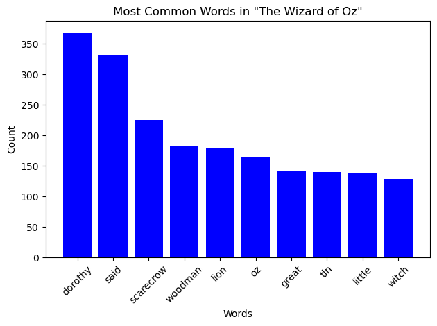

```python
most_common_words = word_counts.most_common(10)  ## Get the most common words
words, counts = zip(*most_common_words)  ## Unzip the words and counts into separate lists

plt.bar(words, counts, color='blue')
plt.xlabel('Words')
plt.ylabel('Count')
plt.title('Most Common Words in "The Wizard of Oz"')
plt.xticks(rotation=45)  ## Rotate x-axis labels for better readability
plt.tight_layout()  ## Adjust layout to prevent overlap
```

```python
try:
    from wordcloud import WordCloud  ## library for generating word clouds
except:
    %pip install wordcloud
    from wordcloud import WordCloud
```

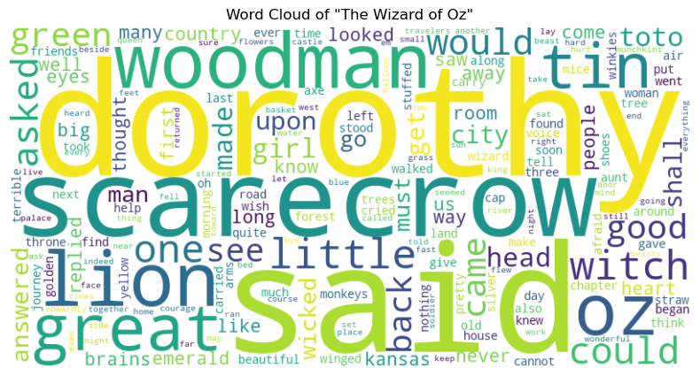

```python
## Visualisation Number 2: Word Cloud

wordcloud = WordCloud(width=800, height=400, background_color='white').generate_from_frequencies(word_counts)  ## Generate a word cloud from the word counts
plt.figure(figsize=(10, 5))  ## Set the figure size
plt.imshow(wordcloud, interpolation='bilinear')  ## Display the word cloud
plt.axis('off')  ## Turn off the axis
plt.title('Word Cloud of "The Wizard of Oz"')

## Optional Save the figure as an image file
plt.savefig('wizard_of_oz_wordcloud.png', bbox_inches='tight', dpi=300)  ## Save the figure as a PNG file
plt.show()  ## Show the word cloud
```

```python
## Step 6: Perform sentiment analysis on the text

nltk.download('vader_lexicon')  ## Download the VADER lexicon for sentiment analysis

from nltk.sentiment import SentimentIntensityAnalyzer  ## library for sentiment analysis

sia = SentimentIntensityAnalyzer()  ## Create a SentimentIntensityAnalyzer object
```

```python
## example Sentence
sentence = "The Wizard of Oz is a wonderful story."
sentiment_scores = sia.polarity_scores(sentence)  ## Get the sentiment scores for the sentence
print(sentiment_scores)  ## Print the sentiment scores for the sentence
```

```
{'neg': 0.0, 'neu': 0.619, 'pos': 0.381, 'compound': 0.5719}
```

```python
## Let's extract the sentences for your book

sentences = nltk.sent_tokenize(cleaned_text)  ## split the cleaned text into sentences using NLTK's sentence tokenizer
print(sentences[:5])  ## Print the first 5 sentences to see the tokenized sentences
```

```
['*** START OF THE PROJECT GUTENBERG EBOOK THE WONDERFUL WIZARD OF OZ ***\r\n\r\n[Illustration]\r\n\r\n\r\n\r\n\r\nThe Wonderful Wizard of Oz\r\n\r\nby L. Frank Baum\r\n\r\n\r\nThis book is dedicated to my good friend & comrade\r\nMy Wife\r\nL.F.B.', 'Contents\r\n\r\n Introduction\r\n Chapter I.', '…
```

```python
def clean_sentence(sentence):
    """Clean a sentence by removing punctuation and converting to lowercase."""
    # Remove asterisks, underscores, and other decorative symbols
    cleaned_sentence = re.sub(r'[_*#<>+=\\/\[\]{}|]', '', sentence)


    # Replace multiple newlines or spaces with single space
    cleaned_sentence = re.sub(r'\s+', ' ', cleaned_sentence)

    # Remove weird characters (non-ASCII)
    cleaned_sentence = cleaned_sentence.encode('ascii', errors='ignore').decode()

    # Strip leading/trailing spaces
    cleaned_sentence = cleaned_sentence.strip()

    return cleaned_sentence
```

```python
cleaned_sentences = []

for sentence in sentences:
    cleaned_sentences.append(clean_sentence(sentence))
```

```python
cleaned_sentences[:100]
```

```
['START OF THE PROJECT GUTENBERG EBOOK THE WONDERFUL WIZARD OF OZ Illustration The Wonderful Wizard of Oz by L. Frank Baum This book is dedicated to my good friend & comrade My Wife L.F.B.',
 'Contents Introduction Chapter I.',
 'The Cyclone Chapter II.',
 'The Council with the Munchkins Chapter III.',
 'How Dorothy Saved the Scarecrow Chapter IV.',
 'The Road Through the Forest Chapter V. The Rescue of the Tin Woodman Chapter VI.',
 'The Cowardly Lion Chapter VII.',
 'The Journey to the Great Oz Chapter VIII.',
 'The Deadly Poppy Field Chapter IX.',
 'The Queen of the Field Mice Chapter X.',
 'The Guardian of the Gates Chapter XI.',
 'The Emerald City of Oz Chapter XII.',
 'The Search for the Wicked Witch Chapter XIII.',
 'The Rescue Chapter XIV.',
 'The Winged Monkeys Chapter XV.',
 'The Discovery of Oz, the Terrible Chapter XVI.',
 'The Magic Art of the Great Humbug Chapter XVII.',
 'How the Balloon Was Launched Chapter XVIII.',
 'Away to the South Chapter XIX.',
 'Attacked by the Fighting Trees Chapter XX.',
 'The Dainty China Country Chapter XXI.',
 'The Lion Becomes the King of Beasts Chapter XXII.',
 'The Country of the Quadlings Chapter XXIII.',
 'Glinda The Good Witch Grants Dorothys Wish Chapter XXIV.',
 'Home Again Introduction Folklore, legends, myths and fairy tales have followed childhood through the ages, for every healthy youngster has a wholesome and instinctive love for stories fantastic, marvelous and manifestly unreal.',
 'The winged fairies of Grimm and Andersen have brought more happiness to childish hearts than all other human creations.',
 'Yet the old time fairy tale, having served for generations, may now be classed as historical in the childrens library; for the time has come for a series of newer wonder tales in which the stereotyped genie, dwarf and fairy are eliminated, together with all the horrible and blood-curdling incident…
 'Modern education includes morality; therefore the modern child seeks only entertainment in its wonder tales and gladly dispenses with all disagreeable incident.',
 'Having this thought in mind, the story of The Wonderful Wizard of Oz was written solely to please children of today.',
 'It aspires to being a modernized fairy tale, in which the wonderment and joy are retained and the heartaches and nightmares are left out.',
 'L. Frank Baum Chicago, April, 1900.',
 'The Wonderful Wizard of Oz Chapter I The Cyclone Dorothy lived in the midst of the great Kansas prairies, with Uncle Henry, who was a farmer, and Aunt Em, who was the farmers wife.',
 'Their house was small, for the lumber to build it had to be carried by wagon many miles.',
 'There were four walls, a floor and a roof, which made one room; and this room contained a rusty looking cookstove, a cupboard for the dishes, a table, three or four chairs, and the beds.',
 'Uncle Henry and Aunt Em had a big bed in one corner, and Dorothy a little bed in another corner.',
 'There was no garret at all, and no cellarexcept a small hole dug in the ground, called a cyclone cellar, where the family could go in case one of those great whirlwinds arose, mighty enough to crush any building in its path.',
 'It was reached by a trap door in the middle of the floor, from which a ladder led down into the small, dark hole.',
 'When Dorothy stood in the doorway and looked around, she could see nothing but the great gray prairie on every side.',
 'Not a tree nor a house broke the broad sweep of flat country that reached to the edge of the sky in all directions.',
 'The sun had baked the plowed land into a gray mass, with little cracks running through it.',
```

[output cut: 45 more lines]

```
 'Chapter II The Council with the Munchkins She was awakened by a shock, so sudden and severe that if Dorothy had not been lying on the soft bed she might have been hurt.',
 'As it was, the jar made her catch her breath and wonder what had happened; and Toto put his cold little nose into her face and whined dismally.',
 'Dorothy sat up and noticed that the house was not moving; nor was it dark, for the bright sunshine came in at the window, flooding the little room.',
 'She sprang from her bed and with Toto at her heels ran and opened the door.',
 'The little girl gave a cry of amazement and looked about her, her eyes growing bigger and bigger at the wonderful sights she saw.',
 'The cyclone had set the house down very gentlyfor a cyclonein the midst of a country of marvelous beauty.',
 'There were lovely patches of greensward all about, with stately trees bearing rich and luscious fruits.',
 'Banks of gorgeous flowers were on every hand, and birds with rare and brilliant plumage sang and fluttered in the trees and bushes.',
 'A little way off was a small brook, rushing and sparkling along between green banks, and murmuring in a voice very grateful to a little girl who had lived so long on the dry, gray prairies.',
 'While she stood looking eagerly at the strange and beautiful sights, she noticed coming toward her a group of the queerest people she had ever seen.',
 'They were not as big as the grown folk she had always been used to; but neither were they very small.',
 'In fact, they seemed about as tall as Dorothy, who was a well-grown child for her age, although they were, so far as looks go, many years older.',
 'Three were men and one a woman, and all were oddly dressed.',
 'They wore round hats that rose to a small point a foot above their heads, with little bells around the brims that tinkled sweetly as they moved.',
 'The hats of the men were blue; the little womans hat was white, and she wore a white gown that hung in pleats from her shoulders.']
```

```python
results = []

for sentence in cleaned_sentences:
    sentiment_scores = sia.polarity_scores(sentence)  ## Get the sentiment scores for the sentence
    results.append((sentence, sentiment_scores['compound']))  ## Append the sentiment scores to the results list
```

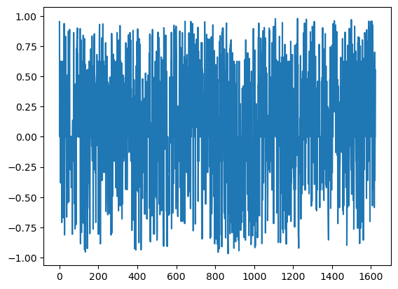

```python
## visualize the sentiment scores

df = pd.DataFrame(results, columns=['Sentence', 'Score'])

plt.plot(df['Score'])
```

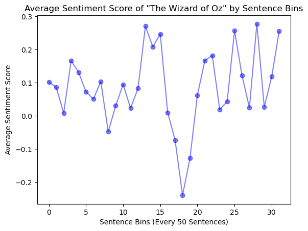

```python
## This makes it hard to see any overall trends so let's calculate the average sentiment score fo every 50 sentences.

## create a dictionary to store the averages
avgScores = {}

## create counter and avgValue variables to keep track
counter = 0
avgValue = 0

## loop through the results
for i in range(len(results)):
    avgValue += results[i][1]  ## add the sentiment score to the avgValue
    counter += 1  ## increment the counter

    ## when we're ready to go to the next bin, we first calculate the average for the current bin, and reset the counter and avgValue
    if counter == 50:
        avgScores[i // 50] = avgValue / 50
        counter = 0
        avgValue = 0

plt.plot(list(avgScores.keys()), list(avgScores.values()), marker='o', linestyle='-', color='blue', alpha=0.5)
plt.xlabel('Sentence Bins (Every 50 Sentences)')
plt.ylabel('Average Sentiment Score')
plt.title('Average Sentiment Score of "The Wizard of Oz" by Sentence Bins')
```

### Congratulations you've finished up the introduction to python tutorial!

If you're interested in working through some other text analysis examples or challenges:

1. Create a heatmap of word frequencies by chapter.
2. Test whether there's a difference in sentiment for shorter sentences versus longer sentences. What built-in function could you use to calculate the length of the sentence? How might you modify your existing code to add sentence length as a variable?
3. Try topic modeling to identify what words cluster together using scikit-learn.

You can also check out the numerous Constellate tutorials available (for a limited time!). Including but not limited to:

- Significant Terms Analysis
- Data Visualization
- Building a language model
- Sentiment Analysis